# Homework1

Zhipeng Chen

9/23/2021

## 1

### a

```r
a <- 0.7
b <- 0.2
c <- 0.1
```

$0.7_{10}$=$0.10110011001_{2}$  
$0.2_{10}$=$0.00110011001_{2}$  
$0.1_{10}$=$0.00011001100_{2}$

### b, c, d

```r
(a + b) + c == 1
```

```
## [1] FALSE
```

```r
a + (b + c) == 1
```

```
## [1] TRUE
```

```r
(a + c) + b == 1
```

```
## [1] TRUE
```

### e

The question b is false and the other two are both true. This may be caused by the rounding error. The real number cannot be exactly represented by floating-point computation. For example, the decimal number 0.1 has a finite decimal representation, in binary it has an infinite repeating representation.

## 2

### a

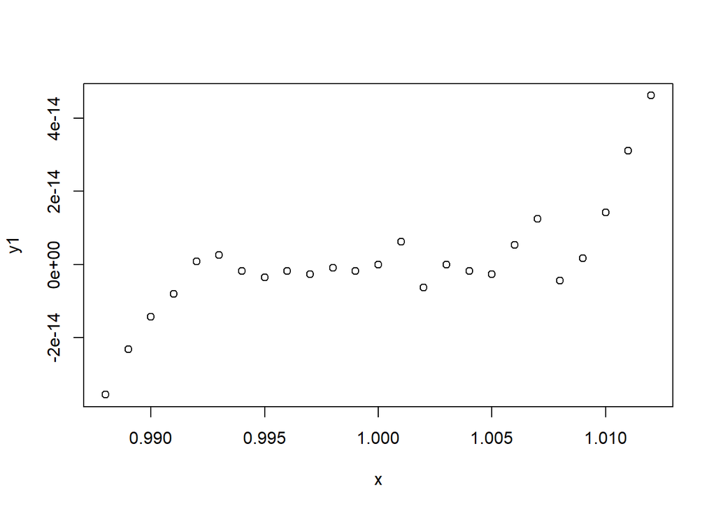

```r
x <- 0.001 * (988:1012)
y1 <- x^7 - 7*x^6 + 21*x^5 - 35*x^4 + 35*x^3 - 21*x^2 + 7*x - 1
plot(x, y1)
```

### b

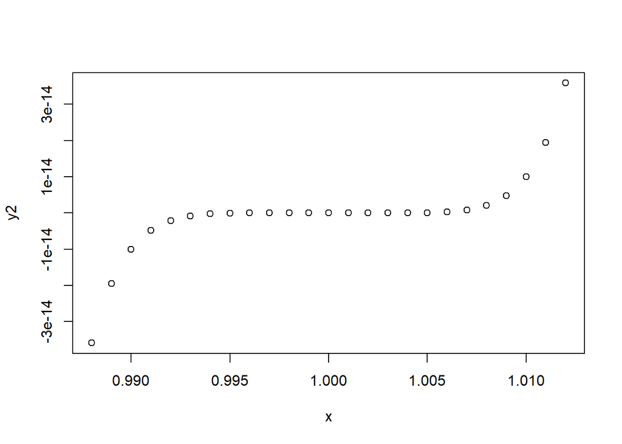

```r
y2 <- (x - 1)^7
plot(x, y2)
```

## 3

### a

```r
u <- matrix(c(1, 2, 3, 3, 2, 1), 6, 1)
ut <- t(u)
d <- ut %*% u
part2 <- (2/as.vector(d)) * (u %*% ut)
U <- diag(6) - part2
U
```

```
##             [,1]       [,2]       [,3]       [,4]       [,5]        [,6]
## [1,]  0.92857143 -0.1428571 -0.2142857 -0.2142857 -0.1428571 -0.07142857
## [2,] -0.14285714  0.7142857 -0.4285714 -0.4285714 -0.2857143 -0.14285714
## [3,] -0.21428571 -0.4285714  0.3571429 -0.6428571 -0.4285714 -0.21428571
## [4,] -0.21428571 -0.4285714 -0.6428571  0.3571429 -0.4285714 -0.21428571
## [5,] -0.14285714 -0.2857143 -0.4285714 -0.4285714  0.7142857 -0.14285714
## [6,] -0.07142857 -0.1428571 -0.2142857 -0.2142857 -0.1428571  0.92857143
```

### b

```r
C <- U %*% U
largest_off_diag <- max(C[lower.tri(C) | upper.tri(C)])
largest_off_diag
```

```
## [1] -2.775558e-17
```

```r
smallest_off_diag <- min(C[lower.tri(C) | upper.tri(C)])
smallest_off_diag
```

```
## [1] -1.491862e-16
```

### c

```r
largest_diag <- max(diag(C))
largest_diag
```

```
## [1] 1
```

```r
smallest_diag <- min(diag(C))
smallest_diag
```

```
## [1] 1
```

### d

```r
U %*% u
```

```
##      [,1]
## [1,]   -1
## [2,]   -2
## [3,]   -3
## [4,]   -3
## [5,]   -2
## [6,]   -1
```

### e

```r
s <- max(rowSums(abs(U)))
s
```

```
## [1] 2.285714
```

### f

```r
print(U[3,])
```

```
## [1] -0.2142857 -0.4285714  0.3571429 -0.6428571 -0.4285714 -0.2142857
```

### g

```r
print(U[3,2])
```

```
## [1] -0.4285714
```

### h

```r
A <- U[,1:3]
P <- A %*% t(A)
P
```

```
##               [,1]          [,2]          [,3]          [,4]          [,5]
## [1,]  9.285714e-01 -1.428571e-01 -2.142857e-01 -2.775558e-17 -2.775558e-17
## [2,] -1.428571e-01  7.142857e-01 -4.285714e-01 -5.551115e-17 -2.775558e-17
## [3,] -2.142857e-01 -4.285714e-01  3.571429e-01 -2.775558e-17 -5.551115e-17
## [4,] -2.775558e-17 -5.551115e-17 -2.775558e-17  6.428571e-01  4.285714e-01
## [5,] -2.775558e-17 -2.775558e-17 -5.551115e-17  4.285714e-01  2.857143e-01
## [6,] -1.387779e-17 -1.387779e-17 -2.775558e-17  2.142857e-01  1.428571e-01
##               [,6]
## [1,] -1.387779e-17
## [2,] -1.387779e-17
## [3,] -2.775558e-17
## [4,]  2.142857e-01
## [5,]  1.428571e-01
## [6,]  7.142857e-02
```

### i

```r
max(rowSums(abs(((P %*% P) - P))))
```

```
## [1] 2.299748e-16
```

```r
library(matrixcalc)
is.idempotent.matrix(P)
```

```
## [1] TRUE
```

### j

```r
B <- U[,(ncol(U)-2):ncol(U)]
Q <- B %*% t(B)
Q
```

```
##               [,1]          [,2]          [,3]          [,4]          [,5]
## [1,]  7.142857e-02  1.428571e-01  2.142857e-01 -2.602085e-17 -1.214306e-17
## [2,]  1.428571e-01  2.857143e-01  4.285714e-01 -5.204170e-17 -2.428613e-17
## [3,]  2.142857e-01  4.285714e-01  6.428571e-01 -2.775558e-17 -3.816392e-17
## [4,] -2.602085e-17 -5.204170e-17 -2.775558e-17  3.571429e-01 -4.285714e-01
## [5,] -1.214306e-17 -2.428613e-17 -3.816392e-17 -4.285714e-01  7.142857e-01
## [6,] -1.387779e-17 -2.775558e-17 -2.775558e-17 -2.142857e-01 -1.428571e-01
##               [,6]
## [1,] -1.387779e-17
## [2,] -2.775558e-17
## [3,] -2.775558e-17
## [4,] -2.142857e-01
## [5,] -1.428571e-01
## [6,]  9.285714e-01
```

### k

```r
max(rowSums(abs(((Q %*% Q) - Q))))
```

```
## [1] 2.299748e-16
```

```r
is.idempotent.matrix(Q)
```

```
## [1] TRUE
```

### l

```r
P + Q
```

```
##               [,1]          [,2]          [,3]          [,4]          [,5]
## [1,]  1.000000e+00 -2.775558e-17 -5.551115e-17 -5.377643e-17 -3.989864e-17
## [2,] -2.775558e-17  1.000000e+00 -1.110223e-16 -1.075529e-16 -5.204170e-17
## [3,] -5.551115e-17 -1.110223e-16  1.000000e+00 -5.551115e-17 -9.367507e-17
## [4,] -5.377643e-17 -1.075529e-16 -5.551115e-17  1.000000e+00 -1.665335e-16
## [5,] -3.989864e-17 -5.204170e-17 -9.367507e-17 -1.665335e-16  1.000000e+00
## [6,] -2.775558e-17 -4.163336e-17 -5.551115e-17 -5.551115e-17 -2.775558e-17
##               [,6]
## [1,] -2.775558e-17
## [2,] -4.163336e-17
## [3,] -5.551115e-17
## [4,] -5.551115e-17
## [5,] -2.775558e-17
## [6,]  1.000000e+00
```

## 4

```r
oringp <- read.table("E:\\OneDrive\\Study\\PhD of Biostatistics\\4-Data Analysis\\HW1\\oringp.dat")
oringp <- oringp[complete.cases(oringp),]
cor(oringp$V4, oringp$V5)
```

```
## [1] -0.5613284
```

## 5

### a

- All R functions have three parts:
  - the `formals()`, the list of **arguments** which controls how you can call the function
  - the `body()`, the **code** inside the function
  - the `environment()`, the “map” of the location of the function’s variables

### b

```r
x <- 10
f1 <- function(x){
    function(){
        x + 10
    }
}
f1(1)()
```

```
## [1] 11
```

### c

```r
mean(x = c(1:10, NA), na.rm = TRUE)
```

```
## [1] 5.5
```

### d

```r
f2 <- function(a, b){
  return(a * 10)
}
f2(10, stop("This is an error!"))
```

```
## [1] 100
```

There is no error when called since we don’t use b when call the function.

## 6

### a

```r
matrixA <- function(n){
  stA <- matrix(0, nrow = n, ncol = n)
  for (i in 1:n){
    for (j in 1:n){
      stA[i, j] = 1 / (abs(i - j) + 1)
    }
  }
  stA
}
```

### b

```r
matrixA(10)
```

```
##            [,1]      [,2]      [,3]      [,4]      [,5]      [,6]      [,7]
##  [1,] 1.0000000 0.5000000 0.3333333 0.2500000 0.2000000 0.1666667 0.1428571
##  [2,] 0.5000000 1.0000000 0.5000000 0.3333333 0.2500000 0.2000000 0.1666667
##  [3,] 0.3333333 0.5000000 1.0000000 0.5000000 0.3333333 0.2500000 0.2000000
##  [4,] 0.2500000 0.3333333 0.5000000 1.0000000 0.5000000 0.3333333 0.2500000
##  [5,] 0.2000000 0.2500000 0.3333333 0.5000000 1.0000000 0.5000000 0.3333333
##  [6,] 0.1666667 0.2000000 0.2500000 0.3333333 0.5000000 1.0000000 0.5000000
##  [7,] 0.1428571 0.1666667 0.2000000 0.2500000 0.3333333 0.5000000 1.0000000
##  [8,] 0.1250000 0.1428571 0.1666667 0.2000000 0.2500000 0.3333333 0.5000000
##  [9,] 0.1111111 0.1250000 0.1428571 0.1666667 0.2000000 0.2500000 0.3333333
## [10,] 0.1000000 0.1111111 0.1250000 0.1428571 0.1666667 0.2000000 0.2500000
##            [,8]      [,9]     [,10]
##  [1,] 0.1250000 0.1111111 0.1000000
##  [2,] 0.1428571 0.1250000 0.1111111
##  [3,] 0.1666667 0.1428571 0.1250000
##  [4,] 0.2000000 0.1666667 0.1428571
##  [5,] 0.2500000 0.2000000 0.1666667
##  [6,] 0.3333333 0.2500000 0.2000000
##  [7,] 0.5000000 0.3333333 0.2500000
##  [8,] 1.0000000 0.5000000 0.3333333
##  [9,] 0.5000000 1.0000000 0.5000000
## [10,] 0.3333333 0.5000000 1.0000000
```

### c

```r
chol(matrixA(10))
```

```
##       [,1]      [,2]      [,3]      [,4]      [,5]      [,6]      [,7]
##  [1,]    1 0.5000000 0.3333333 0.2500000 0.2000000 0.1666667 0.1428571
##  [2,]    0 0.8660254 0.3849002 0.2405626 0.1732051 0.1347151 0.1099715
##  [3,]    0 0.0000000 0.8606630 0.3765400 0.2323790 0.1656776 0.1278699
##  [4,]    0 0.0000000 0.0000000 0.8589803 0.3735049 0.2291962 0.1626144
##  [5,]    0 0.0000000 0.0000000 0.0000000 0.8581924 0.3719766 0.2275279
##  [6,]    0 0.0000000 0.0000000 0.0000000 0.0000000 0.8577456 0.3710713
##  [7,]    0 0.0000000 0.0000000 0.0000000 0.0000000 0.0000000 0.8574620
##  [8,]    0 0.0000000 0.0000000 0.0000000 0.0000000 0.0000000 0.0000000
##  [9,]    0 0.0000000 0.0000000 0.0000000 0.0000000 0.0000000 0.0000000
## [10,]    0 0.0000000 0.0000000 0.0000000 0.0000000 0.0000000 0.0000000
##             [,8]       [,9]      [,10]
##  [1,] 0.12500000 0.11111111 0.10000000
##  [2,] 0.09278844 0.08018754 0.07056503
##  [3,] 0.10374063 0.08709090 0.07494940
##  [4,] 0.12499247 0.10105651 0.08458911
##  [5,] 0.16096174 0.12340555 0.09955033
##  [6,] 0.22651321 0.15993584 0.12240439
##  [7,] 0.37047945 0.22583697 0.15924172
##  [8,] 0.85726783 0.37006563 0.22535737
##  [9,] 0.00000000 0.85712760 0.36976194
## [10,] 0.00000000 0.00000000 0.85702216
```

### d

```r
det(matrixA(10))
```

```
## [1] 0.06476168
```